# Bechdel Test Revisited by Movie Gender

Gaëlle Guillou

10/20/2018

### The “progressiveness test”

This “new bechdel test” assignment has inspired me to a new approach to gender distribution in movies. The problem is not only the blatant, factual gender inequality, it is also the way female characters are depicted. Family or romance movies have a greater share of women than will have action or adventure movies. This kind of storyline will perpetuate gender stereotypes which serve as excuses for the movie business to build an unequal distribution.

This new approach will be based on the “progressiveness” of a movie in terms of woman representation. We will first determine the effects of movie genres on the part of the female distribution, then try to predict a “reasonable” level of female distribution according to the expected effect of the genres.

Overall, the goal is to spot the movies that outdid themselves in terms of female representation compared to the industry standards.

### Loading libraries

```r
# Library import

library(tidyverse)
library(magrittr)
library(ggplot2)
library(readr)
library(lubridate)
library(jsonlite)
library(splitstackshape)

# Setting system locale to get accents

Sys.setlocale(locale="en_US.UTF-8")
```

```
## [1] "en_US.UTF-8/en_US.UTF-8/en_US.UTF-8/C/en_US.UTF-8/C"
```

### Introducing and loading the datasets

**FiveThirtyEight Dataset**

```r
# Loading data

cast_gender <- read_csv("https://raw.githubusercontent.com/fivethirtyeight/data/master/next-bechdel/nextBechdel_castGender.csv")

glimpse(cast_gender)
```

```
## Observations: 2,075
## Variables: 6
## $ MOVIE          <chr> "Tyler Perry’s Boo! A Madea Halloween", "Tyler ...
## $ ACTOR          <chr> "Tyler Perry", "Cassi Davis", "Patrice Lovely",...
## $ CHARACTER_NAME <chr> "Madea/Joe/Brian", "Aunt Bam", "Hattie", "Jonat...
## $ TYPE           <chr> "Leading", "Supporting", "Supporting", "Support...
## $ BILLING        <int> 1, 2, 3, 4, 5, 6, 7, 8, 9, 10, 11, 12, 13, 14, ...
## $ GENDER         <chr> "Male", "Female", "Female", "Male", "Female", "...
```

The current data only provides us insights on distribution of roles in the movies. Let’s mix it up a little with data about the movies.

**Kaggle’s Movie Dataset**

We will be using Kaggle’s movie dataset to enrich our current information.

https://www.kaggle.com/rounakbanik/the-movies-dataset/version/7

We will be focusing on the following dataset : movies_metadata.csv

```r
movies <- read_csv("movies_metadata.csv")

glimpse(movies)
```

```
## Observations: 45,466
## Variables: 24
## $ adult                 <chr> "False", "False", "False", "False", "Fal...
## $ belongs_to_collection <chr> "{'id': 10194, 'name': 'Toy Story Collec...
## $ budget                <int> 30000000, 65000000, 0, 16000000, 0, 6000...
## $ genres                <chr> "[{'id': 16, 'name': 'Animation'}, {'id'...
## $ homepage              <chr> "http://toystory.disney.com/toy-story", ...
## $ id                    <int> 862, 8844, 15602, 31357, 11862, 949, 118...
## $ imdb_id               <chr> "tt0114709", "tt0113497", "tt0113228", "...
## $ original_language     <chr> "en", "en", "en", "en", "en", "en", "en"...
## $ original_title        <chr> "Toy Story", "Jumanji", "Grumpier Old Me...
## $ overview              <chr> "Led by Woody, Andy's toys live happily ...
## $ popularity            <dbl> 21.946943, 17.015539, 11.712900, 3.85949...
## $ poster_path           <chr> "/rhIRbceoE9lR4veEXuwCC2wARtG.jpg", "/vz...
## $ production_companies  <chr> "[{'name': 'Pixar Animation Studios', 'i...
## $ production_countries  <chr> "[{'iso_3166_1': 'US', 'name': 'United S...
## $ release_date          <date> 1995-10-30, 1995-12-15, 1995-12-22, 199...
## $ revenue               <int> 373554033, 262797249, 0, 81452156, 76578...
## $ runtime               <dbl> 81, 104, 101, 127, 106, 170, 127, 97, 10...
## $ spoken_languages      <chr> "[{'iso_639_1': 'en', 'name': 'English'}...
## $ status                <chr> "Released", "Released", "Released", "Rel...
## $ tagline               <chr> NA, "Roll the dice and unleash the excit...
## $ title                 <chr> "Toy Story", "Jumanji", "Grumpier Old Me...
## $ video                 <chr> "False", "False", "False", "False", "Fal...
## $ vote_average          <dbl> 7.7, 6.9, 6.5, 6.1, 5.7, 7.7, 6.2, 5.4, ...
## $ vote_count            <int> 5415, 2413, 92, 34, 173, 1886, 141, 45, ...
```

### Data cleaning : Formatting both datasets in similar ways

```r
# We only want our top-50 2016 movies
# fte refers to Five Thirty Eight

top_50_movies_fte <- unique(cast_gender$MOVIE)

top_50_movies_kaggle <- movies %>%
  filter(original_title %in% top_50_movies_fte) %>%
  filter(year(release_date) == 2016) %>%
  unique() %>%
  select(original_title) %>%
  arrange(original_title)

# For ease of manipulation, we turn it into a list by ignoring the header

top_50_movies_kaggle <- top_50_movies_kaggle[[1]]

length(top_50_movies_kaggle)
```

```
## [1] 44
```

```r
# Unfortunately, only 44 movies seem to have made the cut. Maybe the remaining have typo problems / a different title than in our dataset. Since the dataset is small, we can try to do it manually - otherwise, we could have used regular expressions.
# I also explored the "agrep" function for approximate matching. It worked when it was a space/accentuation problem, but not when part of the movie title was ommited.

# Here are our 6 missing movies :
missing_movies <- top_50_movies_fte[!top_50_movies_fte %in% top_50_movies_kaggle]

#"Tyler Perry’s Boo! A Madea Halloween"
#"Don’t Breathe"
#"Pete’s Dragon"
#"The Conjuring 2: The Enfield Poltergeist"
#"The Divergent Series: Allegiant"
#"Miss Peregrine’s Home for Peculiar Children"

# Choosing "impactful" words in the title allows us a relatively quick fix for filtering and renaming

movies_filtered <- movies %>%
  filter(year(release_date) == 2016) %>%
  filter(
    original_title %in% top_50_movies_fte
    | str_detect(original_title, "Peregrine")
    | str_detect(original_title, "Breathe")
    | str_detect(original_title, "Pete's Dragon")
    | str_detect(original_title, "Conjuring 2")
    | str_detect(original_title, "Madea")
    | str_detect(original_title, "Allegiant")
    )

# Now comes the redundant filtering

movies_filtered[str_detect(movies_filtered$original_title, "Peregrine"), 9] <- "Miss Peregrine’s Home for Peculiar Children"
movies_filtered[str_detect(movies_filtered$original_title, "Breathe"), 9] <- "Don’t Breathe"
movies_filtered[str_detect(movies_filtered$original_title, "Pete's Dragon"), 9] <- "Pete’s Dragon"
movies_filtered[str_detect(movies_filtered$original_title, "Conjuring 2"), 9] <- "The Conjuring 2: The Enfield Poltergeist"
movies_filtered[str_detect(movies_filtered$original_title, "Madea"), 9] <- "Tyler Perry’s Boo! A Madea Halloween"
movies_filtered[str_detect(movies_filtered$original_title, "Allegiant"), 9] <- "The Divergent Series: Allegiant"

# Check if it works

movies_filtered %>%
  filter(original_title %in% top_50_movies_fte)
```

```
## # A tibble: 50 x 24
##    adult belongs_to_coll… budget genres homepage     id imdb_id
##    <chr> <chr>             <int> <chr>  <chr>     <int> <chr>
##  1 False {'id': 448150, … 5.80e7 [{'id… http://… 293660 tt1431…
##  2 False {'id': 131295, … 2.50e8 [{'id… http://… 271110 tt3498…
##  3 False <NA>             1.65e8 [{'id… http://… 284052 tt1211…
##  4 False {'id': 748, 'na… 1.78e8 [{'id… http://… 246655 tt3385…
##  5 False {'id': 283579, … 1.10e8 [{'id… http://… 262504 tt3410…
##  6 False {'id': 435259, … 1.80e8 [{'id… http://… 259316 tt3183…
##  7 False {'id': 427084, … 7.50e7 [{'id… http://… 328111 tt2709…
##  8 False <NA>             1.75e8 [{'id… http://… 297761 tt1386…
##  9 False {'id': 304378, … 1.65e8 [{'id… http://…  47933 tt1628…
## 10 False {'id': 115575, … 1.85e8 [{'id… http://… 188927 tt2660…
## # ... with 40 more rows, and 17 more variables: original_language <chr>,
## #   original_title <chr>, overview <chr>, popularity <dbl>,
## #   poster_path <chr>, production_companies <chr>,
## #   production_countries <chr>, release_date <date>, revenue <int>,
## #   runtime <dbl>, spoken_languages <chr>, status <chr>, tagline <chr>,
## #   title <chr>, video <chr>, vote_average <dbl>, vote_count <int>
```

```r
# And it does !
```

### Exploration : Gender distribution data

The crew gender dataset having been modified (and reduced) since the beginning of the assignment, we choose to focus on the characters and the storytelling.

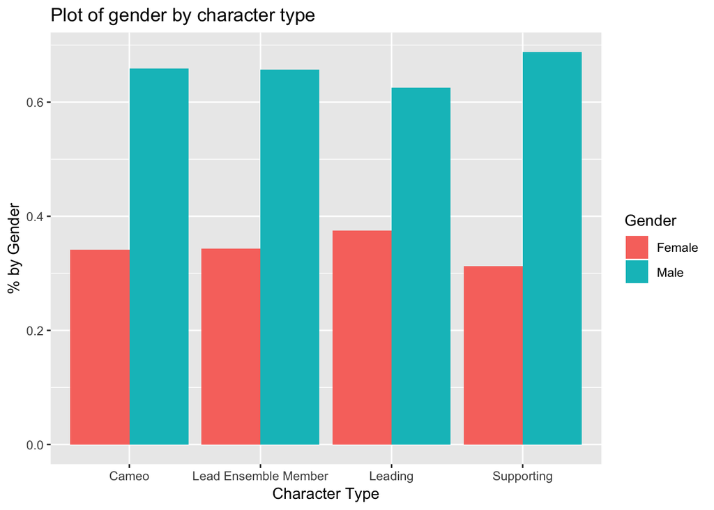

```r
cast_gender %>%
  filter(GENDER != "Unknown") %>%
  group_by(TYPE, GENDER) %>%
  summarise(n = n()) %>%
  mutate(FREQ = n / sum(n)) %>%
  ggplot() +
  aes(TYPE, FREQ) +
  geom_bar(aes(fill = GENDER), position = "dodge", stat = "identity") +
  ggtitle("Plot of gender by character type") +
  xlab("Character Type") +
  ylab("% by Gender") +
  labs(fill = "Gender")
```

Overall, the gender gap is stronger when considering supporting actors, and lower when considering leading actors.

### Data cleaning : Combining movie genre and gender distribution data

Assumptions of the following exploration :

- Because Cameos are rarer and less relevant to the story, we shall choose to ignore them (Cameos are apparitions of actors/personalities in their own names).
- Leading and Lead Ensemble Members only differenciate the number of leads. It is not very relevant to our analysis, so let’s merge them under Leading.

Now, we aim at creating a dataset that contains dummy columns for the genres and a detailed proportion of female characters.

```r
# We now want the raw numbers to merge them with the movies dataset

# Create a dataset that summarises cast distribution by movie

cast_gender_femalefreq <- cast_gender %>%
  filter(GENDER != "Unknown" & TYPE != "Cameo") %>%
  group_by(MOVIE, TYPE, GENDER) %>%
  summarise(n = n()) %>%
  mutate(FREQ = round(n / sum(n), 2)) %>%
  select(-n) %>%
  spread(key = GENDER, value = FREQ) %>%
  select(-Male)

cast_gender_femalefreq[is.na(cast_gender_femalefreq$Female),"Female"] <- 0
cast_gender_femalefreq[str_detect(cast_gender_femalefreq$TYPE, "Lead Ensemble Member"), "TYPE"] <- "Leading"

cast_gender_summary <- cast_gender_femalefreq %>%
  spread(key = TYPE, value = Female)

# Join with our movies dataset

movies_final <- movies_filtered %>%
  select(budget, genres, id, original_title, popularity, release_date, revenue, vote_average) %>%
  inner_join(cast_gender_summary, by = c("original_title" = "MOVIE")) %>%
  rename(lead_female_freq = Leading,
         supporting_female_freq = Supporting,
         genres_original = genres) %>%
  # Made the choice to equally weigh leads and supporting characters. It wouldn't make sense to weigh it according to the number of people because it doesn't properly represent their screening time. At the same time, it wouldn't be fair to consider supporting characters at 20% of the overall frequency just because of their lesser screening time, because they set the "gender tone". A fairly neutral way of weighing them is therefore 50-50, but I admit that it is an important choice in the process.
  mutate(overall_female_freq = (lead_female_freq + supporting_female_freq) / 2)

# Parse json and create a cleaned column of the movie's genre

movies_final$genres <- sapply(
  movies_final$genres_original,
  FUN=function(x) paste(
    fromJSON(
      str_replace_all(x, "'", '"')
      )$name, collapse = ","
    ),
  USE.NAMES = F
  )

# Perform a dummy coding on the genres column

movies_dummy <- concat.split.expanded(movies_final, "genres", sep = ',', type = "character", fill = 0, drop = F)
```

### Exploration : Genres and their impact on role distribution

A useful way to check the impact of each genre on the proportion is to check the correlation matrix.

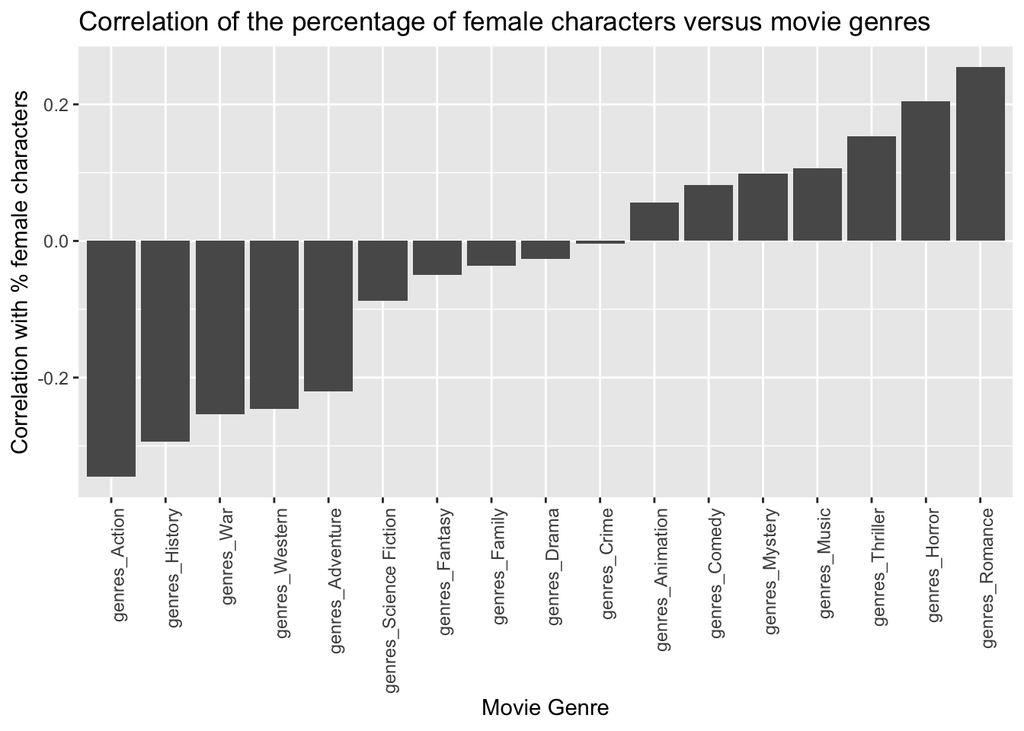

```r
movies_regression_data <- movies_dummy %>%
  select(overall_female_freq, starts_with("genres_")) %>%
  select(-genres_original)

cormat <- cor(movies_regression_data)

corr_freq_female <- rownames_to_column(data.frame(sort(cormat[-1,1])), "genre")
names(corr_freq_female) <- c("genre", "correlation")
corr_freq_female$genre <- factor(corr_freq_female$genre, levels = corr_freq_female$genre[order(corr_freq_female$correlation)])

corr_freq_female %>%
  ggplot() +
  aes(genre, correlation) +
  geom_col() +
  theme(axis.text.x = element_text(angle = 90, hjust = 1)) +
  ggtitle("Correlation of the percentage of female characters versus movie genres") +
  xlab("Movie Genre") +
  ylab("Correlation with % female characters")
```

Some results are expected : Romance movies star more women, while War movies star more men. But Horror movies are surprising : their positive effect on female repartition is similar to Romance movies !

Let’s explore as well the similarity between genres. We aim at clustering the different genres both in relation to their similarity and their impact on gender distribution, instead of just choosing a cutoff value.

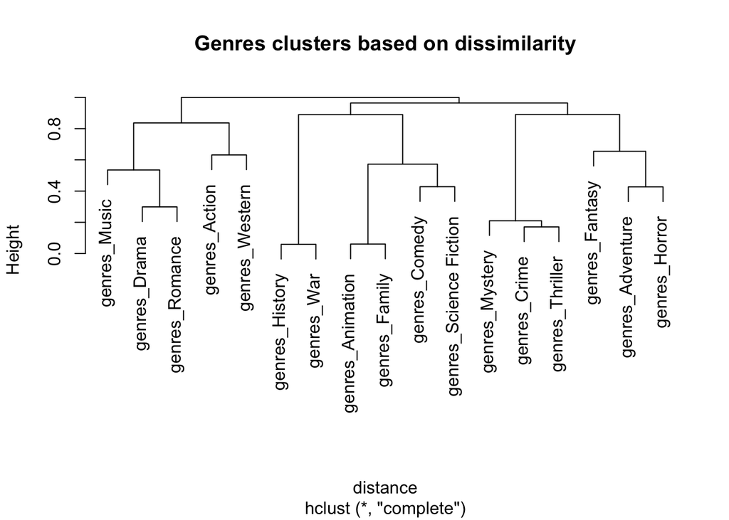

```r
# CLUSTERING BASED ON MOVIES SIMILARITY

# Based on http://research.stowers.org/mcm/efg/R/Visualization/cor-cluster/index.htm
# Limit : our data is not centered

dissimilarity <- 1 - abs(cor(cormat[-1,-1]))
distance <- as.dist(dissimilarity)
hc <- hclust(distance)

plot(hc, main="Genres clusters based on dissimilarity")
```

```r
# We choose 6 clusters because it matches the 2nd rank of nodes

genres_clusters <- rownames_to_column(data.frame(cutree(hc, k = 6)), "genre")
names(genres_clusters) <- c("genre", "cluster")

genres_clusters_freq <- corr_freq_female %>%
  inner_join(genres_clusters) %>%
  mutate(cluster = as.character(cluster))

genres_clusters_freq$genre <- factor(
  genres_clusters_freq$genre, levels = genres_clusters_freq$genre[order(genres_clusters_freq$correlation)]
  )

genres_clusters_freq %>%
  group_by(cluster) %>%
  summarise(average_corr = mean(correlation))
```

```
## # A tibble: 6 x 2
##   cluster average_corr
##   <chr>          <dbl>
## 1 1           -0.295
## 2 2           -0.0218
## 3 3            0.00332
## 4 4            0.0827
## 5 5            0.112
## 6 6           -0.274
```

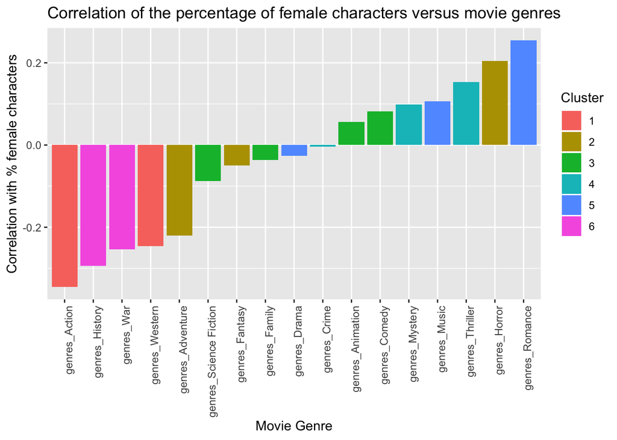

```r
# CLUSTERING BASED ON GENDER DIST. IMPACT

# Overall, it seems the influence of each cluster can be "re-clustered" in terms of its impact -> (Strongly) Negative (1,6), (Slightly) Positive (4,5), Neutral (2,3)

genres_clusters_freq %>%
  ggplot() +
  aes(genre, correlation) +
  geom_col(aes(fill = cluster), position = "dodge", stat = "identity") +
  theme(axis.text.x = element_text(angle = 90, hjust = 1)) +
  ggtitle("Correlation of the percentage of female characters versus movie genres") +
  xlab("Movie Genre") +
  ylab("Correlation with % female characters") +
  labs(fill = "Cluster")
```

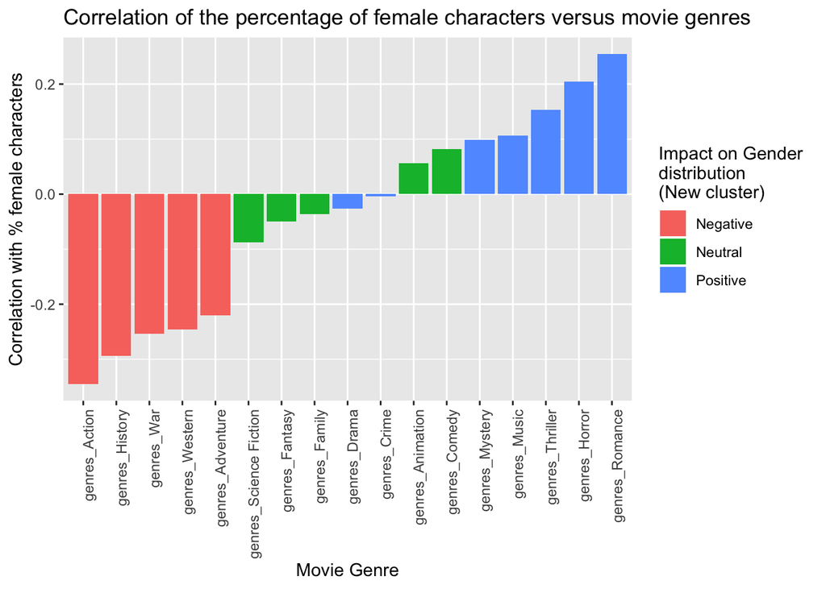

```r
# We realise here the 2nd cluster is not that neutral. Let's just split it in 3.

genres_clusters_freq <- genres_clusters_freq %>%
  mutate(cluster_gender = case_when(
    cluster == "1" | cluster == "6" | (cluster == "2" & correlation < - 0.1) ~ "Negative",
    cluster == "4" | cluster == "5" | (cluster == "2" & correlation > 0.1) ~ "Positive",
    cluster == "3" | (cluster == "2" & abs(correlation) < 0.1) ~ "Neutral"
  ))

genres_clusters_freq %>%
  ggplot() +
  aes(genre, correlation) +
  geom_col(aes(fill = cluster_gender)) +
  theme(axis.text.x = element_text(angle = 90, hjust = 1)) +
  ggtitle("Correlation of the percentage of female characters versus movie genres") +
  xlab("Movie Genre") +
  ylab("Correlation with % female characters") +
  labs(fill = "Impact on Gender \ndistribution \n(New cluster)")
```

```r
# There still remains "Drama" and "Crime" labelled as positive while they have a negative/neutral impact. We choose to keep it that way since we decided to focus on the interactions between genres.
```

Let’s now tag our movies as positive / neutral / negative.

```r
negative_genres <- genres_clusters_freq %>%
  filter(cluster_gender == "Negative") %>%
  select(genre)

neutral_genres <- genres_clusters_freq %>%
  filter(cluster_gender == "Neutral") %>%
  select(genre)

positive_genres <- genres_clusters_freq %>%
  filter(cluster_gender == "Positive") %>%
  select(genre)

movies_dummy$negative <- apply(movies_dummy[, colnames(movies_dummy) %in% c(negative_genres)$genre], 1, function(x) sum(x))
movies_dummy$neutral <- apply(movies_dummy[, colnames(movies_dummy) %in% c(neutral_genres)$genre], 1, function(x) sum(x))
movies_dummy$positive <- apply(movies_dummy[, colnames(movies_dummy) %in% c(positive_genres)$genre], 1, function(x) sum(x))

cor(
  movies_dummy %>%
    select(overall_female_freq, negative, neutral, positive)
)
```

```
##                     overall_female_freq    negative     neutral   positive
## overall_female_freq          1.00000000 -0.49000200 -0.01155893  0.1815774
## negative                    -0.49000200  1.00000000  0.06339132 -0.4030599
## neutral                     -0.01155893  0.06339132  1.00000000 -0.4339774
## positive                     0.18157739 -0.40305991 -0.43397735  1.0000000
```

```r
# Looks coherent !

# Now let's create a score to account for the amount of positive / neutral / negative influences
movies_dummy$genre_score <- (movies_dummy$positive - movies_dummy$negative) / (movies_dummy$positive + movies_dummy$neutral + movies_dummy$negative)
```

### Implementing the “progressiveness” test

We’re working on a progressivity index. So we want to see if the movie has outdone itself compared to what its genre score predicts.

```r
reg <- lm(overall_female_freq ~ genre_score, data = movies_dummy)

summary(reg)
```

```
##
## Call:
## lm(formula = overall_female_freq ~ genre_score, data = movies_dummy)
##
## Residuals:
##      Min       1Q   Median       3Q      Max
## -0.34826 -0.08841 -0.00163  0.11467  0.42748
##
## Coefficients:
##             Estimate Std. Error t value Pr(>|t|)
## (Intercept)  0.35752    0.02408  14.848  < 2e-16 ***
## genre_score  0.13073    0.04356   3.001  0.00426 **
## ---
## Signif. codes:  0 '***' 0.001 '**' 0.01 '*' 0.05 '.' 0.1 ' ' 1
##
## Residual standard error: 0.1695 on 48 degrees of freedom
## Multiple R-squared:  0.158,  Adjusted R-squared:  0.1404
## F-statistic: 9.006 on 1 and 48 DF,  p-value: 0.004259
```

```r
# TEST

movies_dummy$test = movies_dummy$overall_female_freq > predict(reg)

summary(movies_dummy$test)
```

```
##    Mode   FALSE    TRUE
## logical      25      25
```

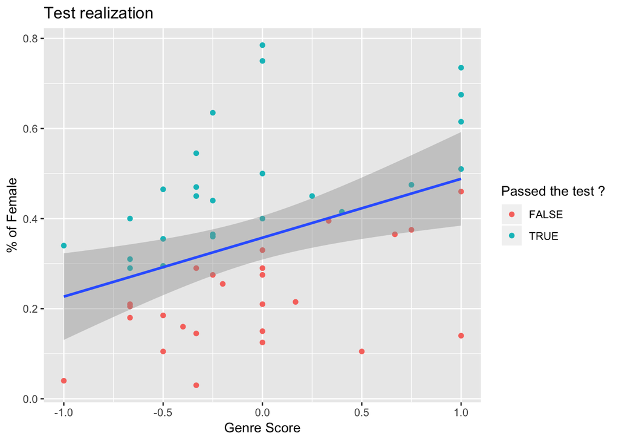

```r
movies_dummy %>%
  ggplot() +
  aes(genre_score, overall_female_freq) +
  geom_point(aes(colour = factor(test))) +
  geom_smooth(method='lm') +
  labs(colour = "Passed the test ?") +
  ggtitle("Test realization") +
  xlab("Genre Score") +
  ylab("% of Female")
```

*Interpretation of the “Genre Score” : the closer it is to 1, the more the movies’ genres have a positive effect on female distribution. The closer it is to -1, the more the movies’ genres have a negative effect on female distribution.*

Because of our (biased) method, we have a 50/50 result. It doesn’t really matter, because what was important was to notice the movies that were progressive, which implies some sort of middle cutoff.

```r
# Some progressive movies

movies_dummy %>%
  filter(test == T) %>%
  select(original_title, overall_female_freq, genres, genre_score) %>%
  head()
```

```
##                       original_title overall_female_freq
## 1         Captain America: Civil War               0.290
## 2                     Doctor Strange               0.355
## 3    The Divergent Series: Allegiant               0.465
## 4                   Star Trek Beyond               0.310
## 5 Batman v Superman: Dawn of Justice               0.400
## 6                           Zootopia               0.440
##                                     genres genre_score
## 1         Adventure,Action,Science Fiction  -0.6666667
## 2 Action,Adventure,Fantasy,Science Fiction  -0.5000000
## 3                Adventure,Science Fiction  -0.5000000
## 4         Action,Adventure,Science Fiction  -0.6666667
## 5                 Action,Adventure,Fantasy  -0.6666667
## 6        Animation,Adventure,Family,Comedy  -0.2500000
```

```r
# Some less progressive movies

movies_dummy %>%
  filter(test == F) %>%
  select(original_title, overall_female_freq, genres, genre_score) %>%
  head()
```

```
##                            original_title overall_female_freq
## 1                                Deadpool               0.205
## 2                       X-Men: Apocalypse               0.275
## 3 Fantastic Beasts and Where to Find Them               0.290
## 4                 The Secret Life of Pets               0.290
## 5                           Suicide Squad               0.255
## 6            Independence Day: Resurgence               0.180
##                                           genres genre_score
## 1                        Action,Adventure,Comedy  -0.6666667
## 2                                Science Fiction   0.0000000
## 3                       Adventure,Family,Fantasy  -0.3333333
## 4                               Animation,Family   0.0000000
## 5 Action,Adventure,Crime,Fantasy,Science Fiction  -0.2000000
## 6               Action,Adventure,Science Fiction  -0.6666667
```

### Conclusion : Strengths and Limitations of this test

**Strength :**

- This test accounts well for movies that make an effort in their genre, a variable often hard to manipulate and take into account.

**Limits :**

- The training set is the same as the one where we perform the test - it is obviously strongly biased.
- The genre score and clusters could be built in other ways - there are strong assumptions.
- It looks a lot like a mean and the test, a simple above and under mean. However, the complexity of the genre score outweighs this simplicity.
- We should not see it as an unilateral test, but consider the fact that men should be as represented as women in “female movies”. For instance, we should not want men to be underrepresented in romance movies, and that “progressiveness” test does not account well for it.